# Boston Crime Analysis and Prediction

Boston Crime Analysis and Prediction

Code Explanation

Web application and API Web Scraping

Analysis

Data Preprocessing Data Analysis Regression Analysis Markov Chain Analysis Shortest Patrol Route Analysis

Demo

Markov Chain Regression API Crime Forecast

# **Boston Crime** Data Analysis

## Data Analysis

Our goal is to find the correlation between temperature and the amount of crime.  
However, we analyze the crime and weather separately, because we might find something interesting here.

### Crime Data

- Load the csv file

```python
import pandas as pd

crime = pd.read_csv('../data/crimeandweather.csv')
crime['OCCURRED_ON_DATE'] = pd.to_datetime(crime['OCCURRED_ON_DATE'])
crime['DATE'] = pd.to_datetime(crime['DATE'])
crime['Lat'] = pd.to_numeric(crime['Lat'])
crime['Long'] = pd.to_numeric(crime['Long'])
print("strat date:", crime['OCCURRED_ON_DATE'].min())
print("end date:", crime['OCCURRED_ON_DATE'].max())
crime.head()
```

```
strat date: 2015-06-15 00:00:00
end date: 2019-11-15 23:59:00
```

|  | OFFENSE_CODE | OFFENSE_CODE_GROUP | OFFENSE_DESCRIPTION | DISTRICT | OCCURRED_ON_DATE | DAY_OF_WEEK | Lat | Long | DATE | TIME | SNOW | TAVG |
| --- | --- | --- | --- | --- | --- | --- | --- | --- | --- | --- | --- | --- |
| 0 | 3005 | NaN | SICK ASSIST | E13 | 2019-11-05 18:00:00 | Tuesday | 42.314621 | -71.106409 | 2019-11-05 | 18:00:00 | 0.0 | 52.0 |
| 1 | 1402 | NaN | VANDALISM | E18 | 2019-11-02 05:09:00 | Saturday | 42.262897 | -71.118855 | 2019-11-02 | 05:09:00 | 0.0 | 45.0 |
| 2 | 724 | Auto Theft | AUTO THEFT | E18 | 2019-10-13 09:28:24 | Sunday | 42.259518 | -71.121563 | 2019-10-13 | 09:28:24 | 0.0 | 59.0 |
| 3 | 724 | Auto Theft | AUTO THEFT | E18 | 2019-10-12 20:11:26 | Saturday | 42.262092 | -71.116710 | 2019-10-12 | 20:11:26 | 0.0 | 56.0 |
| 4 | 727 | Auto Theft | AUTO THEFT - LEASED/RENTED VEHICLE | D14 | 2019-10-12 15:12:43 | Saturday | 42.352375 | -71.135096 | 2019-10-12 | 15:12:43 | 0.0 | 56.0 |

- Create hour column and count the amount of crimes in each hour and plot

```
<function matplotlib.pyplot.show(*args, **kw)>
```

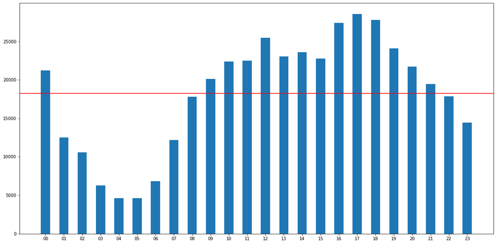

```python
crimehour = pd.DataFrame()
crimehour['HOUR'] = crime.apply(lambda x : x['TIME'][0:2], axis = 1)

crimehourcount = pd.DataFrame()
crimehourcount['COUNT'] = crimehour['HOUR'].value_counts(sort=False)
crimehourcount = crimehourcount.sort_index()

import matplotlib.pyplot as plt
%matplotlib inline

# average line
avg = crime['OCCURRED_ON_DATE'].count()/24

plt.figure(figsize=(20,10))
plt.axhline(y=avg, color='red')
plt.bar(crimehourcount.index.tolist(), crimehourcount['COUNT'], 0.5)
plt.show
```

- Create day column and count the amount of crimes in each day and plot

```
<function matplotlib.pyplot.show(*args, **kw)>
```

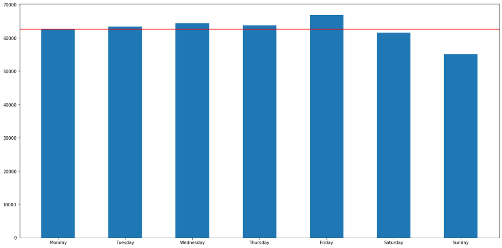

```python
crimedaycount = pd.DataFrame()
daylist = ['Monday', 'Tuesday', 'Wednesday', 'Thursday', 'Friday', 'Saturday', 'Sunday']
crimedaycount['COUNT'] = crime['DAY_OF_WEEK'].value_counts(sort=False)
crimedaycount['DAY'] = crimedaycount.apply(lambda x : daylist.index(x.name), axis = 1)
crimedaycount = crimedaycount.sort_values(['DAY'])

# average line
avg = crime['OCCURRED_ON_DATE'].count()/7

plt.figure(figsize=(20,10))
plt.axhline(y=avg, color='red')
plt.bar(crimedaycount.index.tolist(), crimedaycount['COUNT'], 0.5)
plt.show
```

The crime rates drop on the weekend and peak on Friday. It seems like criminals need to rest too.

- Count the amount of crimes in each district and plot

```
<function matplotlib.pyplot.show(*args, **kw)>
```

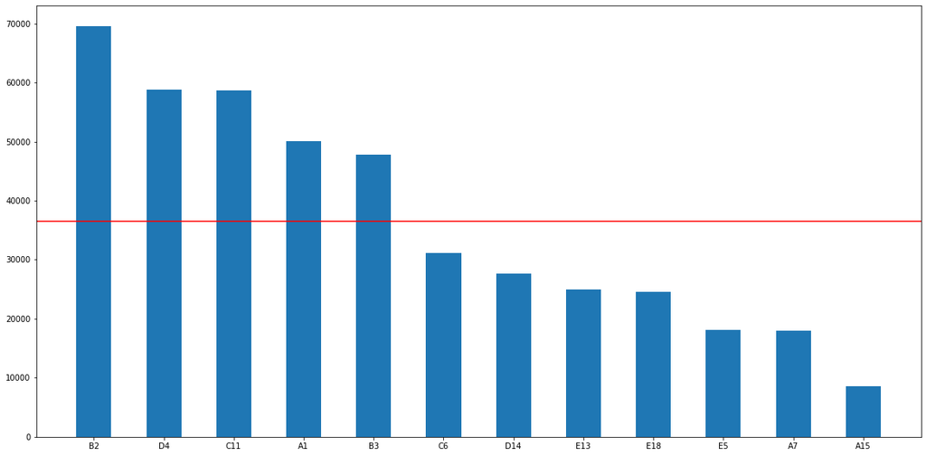

```python
crimedistrictcount = pd.DataFrame()
crimedistrictcount['DISTRICT'] = crime['DISTRICT'].value_counts(sort=False)
crimedistrictcount = crimedistrictcount.sort_values(['DISTRICT'], ascending=False)
crimedistrictcount.head()

# average line
avg = crime['DISTRICT'].count()/crimedistrictcount['DISTRICT'].count()

plt.figure(figsize=(20,10))
plt.axhline(y=avg, color='red')
plt.bar(crimedistrictcount.index.tolist(), crimedistrictcount['DISTRICT'], 0.5)
plt.show
```

The district "B2" has the highest rate of crime, which is Roxbury. The lowest is in the "A15" district, Charlestown.

- Count the amount of vehicle accident in each hour and plot

```
<function matplotlib.pyplot.show(*args, **kw)>
```

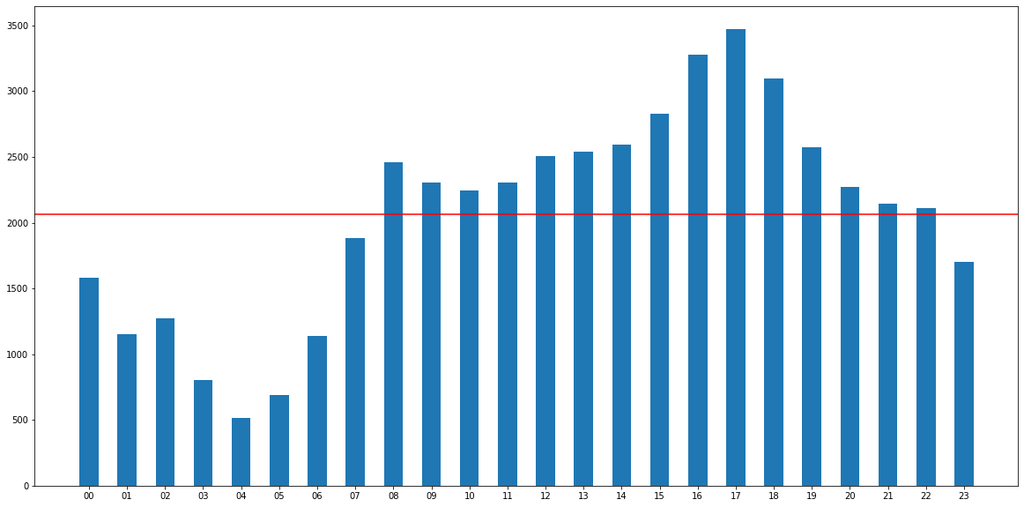

```python
crimemotorhour = pd.DataFrame()
crimemotorhour['HOUR'] = crime[crime['OFFENSE_CODE_GROUP'] == 'Motor Vehicle Accident Response'].apply(lambda x : x['TIME'][0:2], axis = 1)

crimemotorhourcount = pd.DataFrame()
crimemotorhourcount['HOUR'] = crimemotorhour['HOUR'].value_counts(sort=False).index
crimemotorhourcount['COUNT'] = crimemotorhour['HOUR'].value_counts(sort=False).values
crimemotorhourcount = crimemotorhourcount.sort_values(by=['HOUR'])

# average line
avg = crime[crime['OFFENSE_CODE_GROUP'] == 'Motor Vehicle Accident Response']['OCCURRED_ON_DATE'].count()/crimemotorhourcount['HOUR'].count()

plt.figure(figsize=(20,10))
plt.axhline(y=avg, color='red')
plt.bar(crimemotorhourcount['HOUR'].tolist(), crimemotorhourcount['COUNT'], 0.5)
plt.show
```

The vehicle accident rate decrease after the sunset and rise in the morning.  
Maybe because the number of people drives at night is less compare with the day.

- Count the amount of robbery in each day and plot

```
<function matplotlib.pyplot.show(*args, **kw)>
```

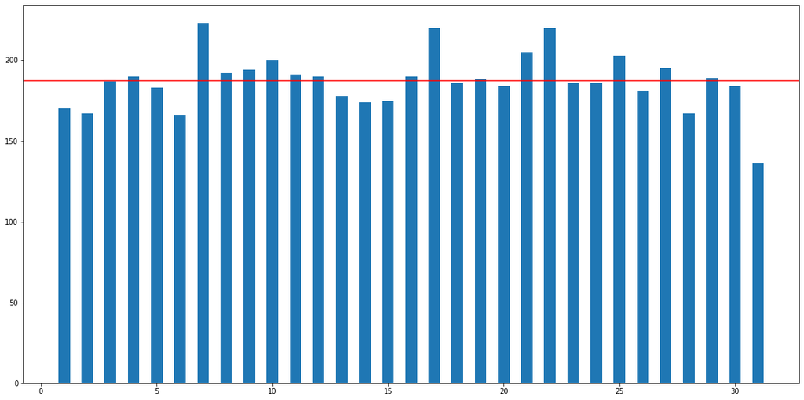

```python
crimerobberyday = pd.DataFrame()
crimerobberyday['DAY'] = crime[crime['OFFENSE_CODE_GROUP'] == 'Robbery'].apply(lambda x : x['DATE'].day, axis = 1)

crimerobberydaycount = pd.DataFrame()
crimerobberydaycount['DAY'] = crimerobberyday['DAY'].value_counts(sort=False).index
crimerobberydaycount['COUNT'] = crimerobberyday['DAY'].value_counts(sort=False).values
crimerobberydaycount = crimerobberydaycount.sort_values(by=['DAY'])

# average line
avg = crime[crime['OFFENSE_CODE_GROUP'] == 'Robbery']['DATE'].count()/crimerobberydaycount['DAY'].count()

plt.figure(figsize=(20,10))
plt.axhline(y=avg, color='red')
plt.bar(crimerobberydaycount['DAY'].tolist(), crimerobberydaycount['COUNT'], 0.5)
plt.show
```

Unfortunately, there is not a significate pattern between robbery and day.  
The 31st day have less crime because not every month have 31 days.

### Weather Data

Since weather data contain only two columns, there is not many things we can analyze.

- Plot temperature distribution

```
<function matplotlib.pyplot.show(*args, **kw)>
```

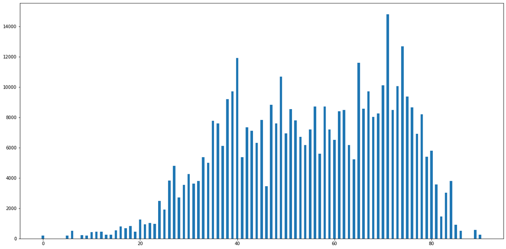

```python
crimetempcount = pd.DataFrame()
crimetempcount['TAVG'] = crime['TAVG'].value_counts(sort=False)
crimetempcount = crimetempcount.sort_index()
crimetempcount.head()

plt.figure(figsize=(20,10))
plt.bar(crimetempcount.index.tolist(), crimetempcount['TAVG'], 0.5)
plt.show
```

The distribution is left-skewed. Most of the temperature is between 40 to 80 degrees.

- Plot average temperature by districts

```
<function matplotlib.pyplot.show(*args, **kw)>
```

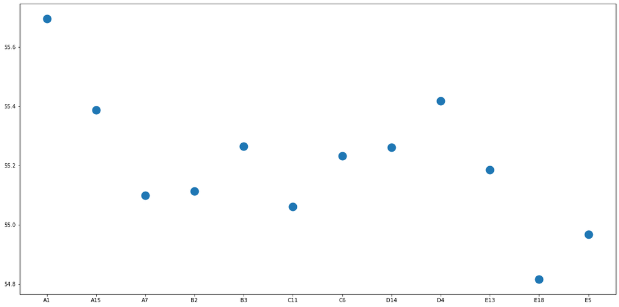

```python
plt.figure(figsize=(20,10))
plt.scatter(crime.groupby(['DISTRICT']).mean()['TAVG'].index, crime.groupby(['DISTRICT']).mean()['TAVG'].values, linewidths =10)
plt.show
```

The difference between the average temperature of each district is within 1 degree, which is close.

The weather data alone is not insightful, we should analyze it with crime data to gain more insight.

### Crime and Weather Data

We want to see the relationship between crimes and weather, and we got the tempurature data by day,  
so we need to group the crimes data by day and marge it with weather data.

- Group the crime data by day and plot

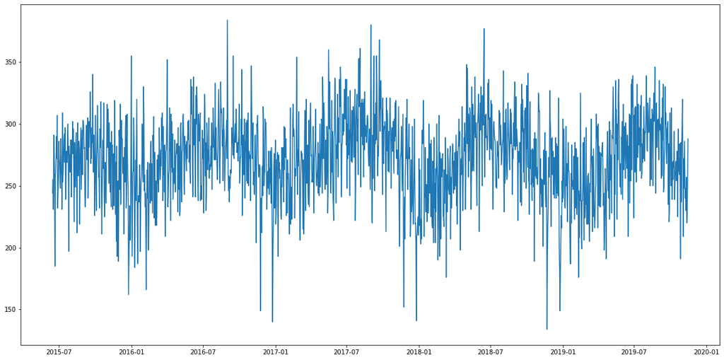

```python
crimedatecount = pd.DataFrame()
crimedatecount['DATE'] = crime['DATE'].value_counts(sort=False).index
crimedatecount['COUNT'] = crime['DATE'].value_counts(sort=False).values
crimedatecount = crimedatecount.sort_values(['DATE'])

from pandas.plotting import register_matplotlib_converters
register_matplotlib_converters()

plt.figure(figsize=(20,10))
plt.plot(crimedatecount['DATE'], crimedatecount['COUNT'])
```

The crime rate is moving like a cycle with peaks at the same time of year.

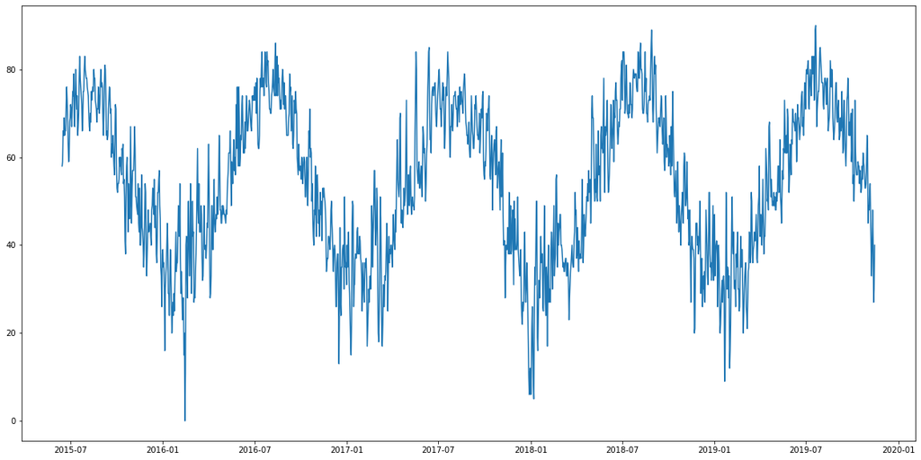

```python
temp = crime[['DATE', 'TAVG']]
temp = temp.drop_duplicates(keep = 'first')
temp = temp.sort_values(by='DATE')

plt.figure(figsize=(20,10))
plt.plot(temp['DATE'], temp['TAVG'])
```

The temperature has a cycle, too, and it looks like the crime data.

- Marge the crime and weather data and plot

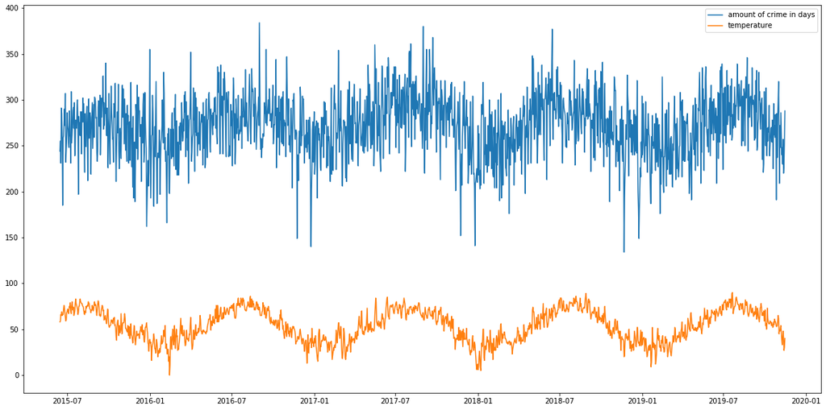

```python
crimedatecountontem = pd.merge(crimedatecount, temp,  how='left', on='DATE')
crimedatecountontem = crimedatecountontem.set_index('DATE')

plt.figure(figsize=(20,10))
plt.plot(crimedatecountontem.index,crimedatecountontem['COUNT'], label="amount of crime in days")
plt.plot(crimedatecountontem.index,crimedatecountontem['TAVG'], label="temperature")
plt.legend()
```

Due to the fluctuations of both data, we cannot tell the relationship between them.  
We can apply the technique in time series analysis, which is moving the average, the technique is used to aggregate data, and the lines will be smoother.

- Apply moving average and plot

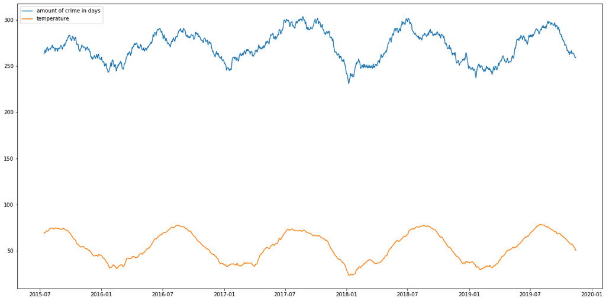

```python
crimetempma = crimedatecountontem.rolling(window=30).mean()
crimetempma = crimetempma.dropna()

plt.figure(figsize=(20,10))
plt.plot(crimetempma.index,crimetempma['COUNT'], label="amount of crime in days")
plt.plot(crimetempma.index,crimetempma['TAVG'], label="temperature")
plt.legend()
```

When the line is smoother, we can see the trend of the lines.  
However, we will make the lines closer for a better interpretation.

- Magnify temperate line

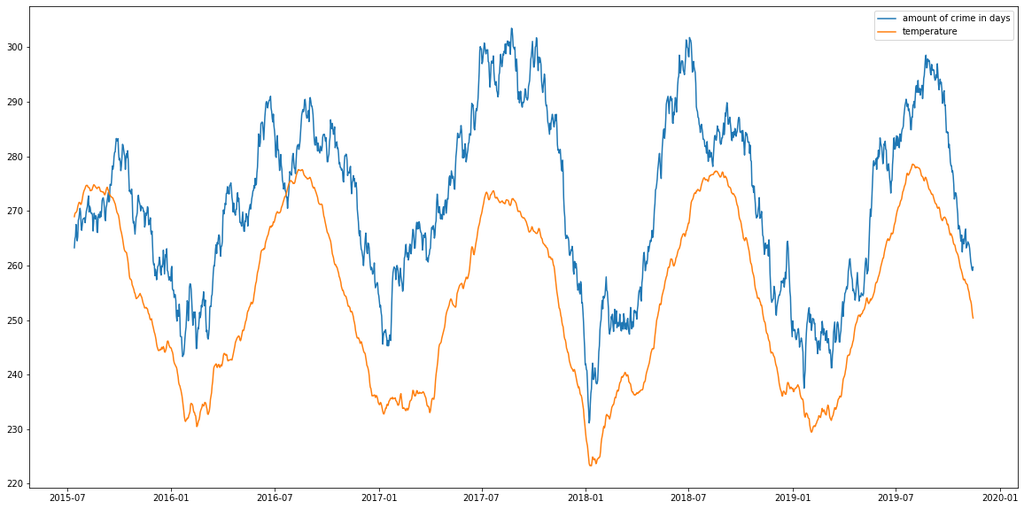

```python
# we add 200 to each temperature, so the lines become closer
crimetempma['TAVG'] = crimetempma['TAVG'] + 200
plt.figure(figsize=(20,10))
plt.plot(crimetempma.index,crimetempma['COUNT'], label="amount of crime in days")
plt.plot(crimetempma.index,crimetempma['TAVG'], label="temperature")
plt.legend()
```

Now we can see that when the temperature rises the crime rate rise too, and when it drops, the crime rate also drops.  
The essential part is when the temperature is sideway, the crime rate also follows the same pattern. (between 2017-01 to 2017-07,2018-01 to 2018-07 and 2019-01 to 2019-07)

Since we know that there is a relationship between two data, we can measure the relationship with linear regression.  
We can group the data by temperatures and count the average number of crimes that happen in the days with the temperature.

- Group a number of crimes on each day by temperature and plot

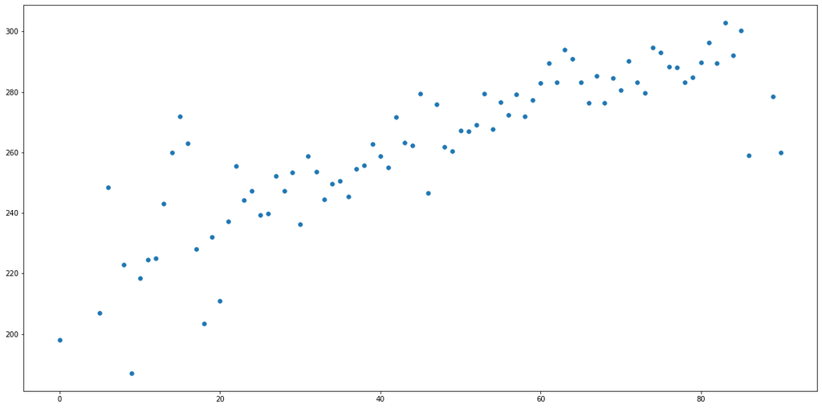

```python
tempandcrime = crimedatecountontem.groupby('TAVG').mean()

plt.figure(figsize=(20,10))
plt.scatter(tempandcrime.index,tempandcrime['COUNT'],s=30)
```

There is clearly a trend between two quantities, but we will look more into this in the next page.

Next: Regression Analysis